# Lab 7

Author

Kyle Bistrain

```r
library(tidyverse)
library(gridExtra)
```

```r
fish <- read_csv(here::here("supporting_artifacts",
                            "learning targets",
                            "BlackfootFish.csv"))
```

**1.Task one**

```r
  sum.na <- function(x) {
    sum(is.na(x))
  }

  fish |>
    summarise(across(.cols = everything(),
                     .fns = ~sum.na(.)
                     )
              )
```

```
# A tibble: 1 × 7
   trip  mark length weight  year section species
  <int> <int>  <int>  <int> <int>   <int>   <int>
1     0     0      0   1796     0       0       0
```

- How many observations have missing values?

  1796
- What variable(s) have missing values present?

  Weight has missing values.

### **2. Task 2 – Visualizing Missing Data**

Unfortunately, these missing values are not for only one `year`, `trip`, or `section` of river.

Create a thoughtful visualization exploring the frequency of missing values across the different years, sections, and trips.

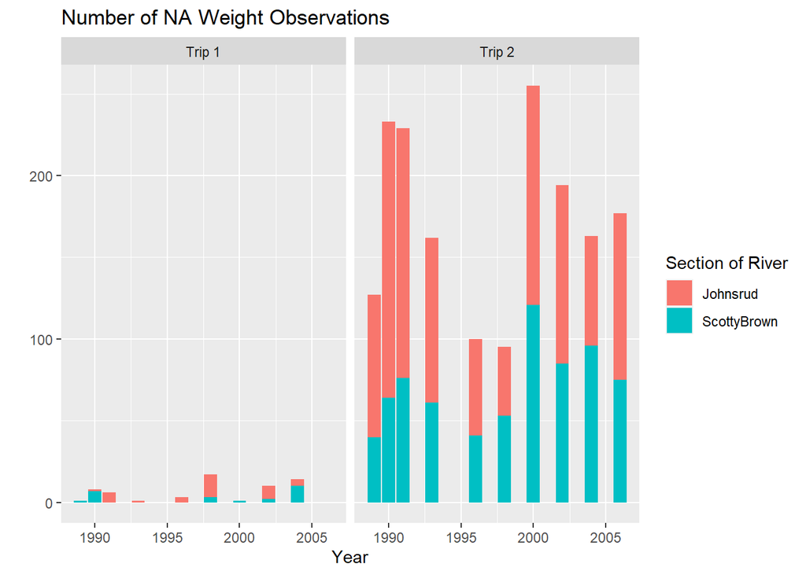

```r
fish |>
  mutate(trip = if_else(trip == 2, "Trip 2", "Trip 1")) |>
  group_by(trip, section, year) |>
  summarise(sum = sum(is.na(weight)),
            .groups = "drop") |>
  ggplot(mapping = aes(x = year ,
                       y = sum,
                       fill = section,
                       postion = "dodge"
                       )
         ) +
  geom_col() +
  facet_wrap(~trip) +
  labs(x = "Year",
       y = "",
       fill = "Section of River",
       title = "Number of NA Weight Observations"
       )
```

## **3. Part Two: Adjusting the Data (Function Writing)**

- The function should take a single vector as its input.
- The function should return the rescaled vector.

*Think about the “efficiency” of your function. Are you calling the **same** function multiple times?*

### **4. Task 2 – Adding Stops**

Now, let’s incorporate some checks into your function! Modify your previous code to create the following checks:

- the function should stop if the input vector is not numeric
- the function should stop if the length of the vector is not greater than 1

*No need to write code here, simply add these stops to your code from Task 1!*

```r
rescale_01 <- function(vec) {
  stopifnot(is.numeric(vec),
            length(vec) > 1
            )
  r <- range(vec, na.rm = TRUE)
  num <- vec - r[1]
  denom <- r[2] - r[1]
  vec <- num/denom
  return(vec)
}
```

### **5. Task 3 - Performing a Simple Test**

First, test your function on the simple vector below. Verify that the maximum of your rescaled vector is 1 and the minimum is 0!

```r
x <- c(1:25, NA)
rescale_01(x)
```

```
 [1] 0.00000000 0.04166667 0.08333333 0.12500000 0.16666667 0.20833333
 [7] 0.25000000 0.29166667 0.33333333 0.37500000 0.41666667 0.45833333
[13] 0.50000000 0.54166667 0.58333333 0.62500000 0.66666667 0.70833333
[19] 0.75000000 0.79166667 0.83333333 0.87500000 0.91666667 0.95833333
[25] 1.00000000         NA
```

### **6. Task 4 - Performing a More Difficult Test**

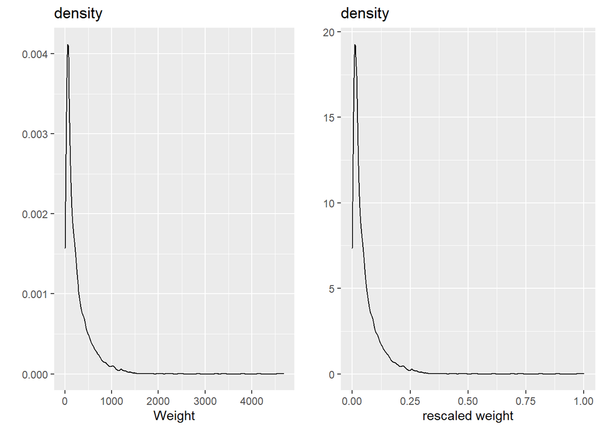

```r
ggp1 <- ggplot(data = fish) +
  geom_density(
    aes( x = weight),
    na.rm = TRUE) +
  labs(y = "",
       x = "Weight",
       title = "density"
       )
ggp2 <- ggplot(data = fish) +
  geom_density(
    aes(x = rescale_01(weight)),
    na.rm = TRUE) +
    labs(y = "",
         x = "rescaled weight",
         title = "density"
         )
grid.arrange(ggp1, ggp2, ncol = 2)
```

source: https://statisticsglobe.com/draw-multiple-ggplot-plots-side-by-side

### **7. Task 5 – Incorportaing Variables**

Suppose you would like for your `rescale()` function to perform operations on a variable within a dataset. Ideally, your function would take a dataframe and a variable name as inputs and return a dataframe where the variable has been rescaled.

Create a `rescale_column()` that accepts two arguments, (1) a dataframe, and (2) the name(s) of the variable(s) to be rescaled. The body of the function should call the original `rescale_01()` function you wrote previously.

```r
rescale_column <- function(dtframe, vars) {
    stopifnot(is.data.frame(dtframe))
    dtframe <- dtframe |>
      mutate( across(.cols = {{ vars }}, .fns = rescale_01))
  return (dtframe)
}
```

### **8. Task 6 – Another Function Test**

Alright, now let’s put your `rescale_column()` function to work! Use your `rescale_column()` function to rescale **both** the `length` and `weight` columns.

**I expect that you carry out this process by calling the `rescale()` function *one* time!**

```r
rescale_column(fish,`length`:`weight`)
```

```
# A tibble: 18,352 × 7
    trip  mark length  weight  year section  species
   <dbl> <dbl>  <dbl>   <dbl> <dbl> <chr>    <chr>
 1     1     0  0.280 0.0374   1989 Johnsrud RBT
 2     1     0  0.280 0.0406   1989 Johnsrud RBT
 3     1     0  0.277 0.0524   1989 Johnsrud RBT
 4     1     0  0.315 0.0588   1989 Johnsrud RBT
 5     1     0  0.305 0.0641   1989 Johnsrud RBT
 6     1     0  0.358 0.0812   1989 Johnsrud RBT
 7     1     0  0.261 0.0363   1989 Johnsrud RBT
 8     1     0  0.148 0.00855  1989 Johnsrud RBT
 9     1     0  0.203 0.0171   1989 Johnsrud RBT
10     1     0  0.145 0.00748  1989 Johnsrud RBT
# … with 18,342 more rows
```